# Univariate Plots Section

## Description two

Residual sugar has a bimodal distribution plotted on log x scale, which suggusts that there are two distinct populations of wines with distinct residual sugar. Density is negatively correlated with the alcohol. When the data is plot with residual sugar as the bucket, two populations are clearly seen from the plot: wines of higher residual sugar tend to have a larger density.

## Plot three

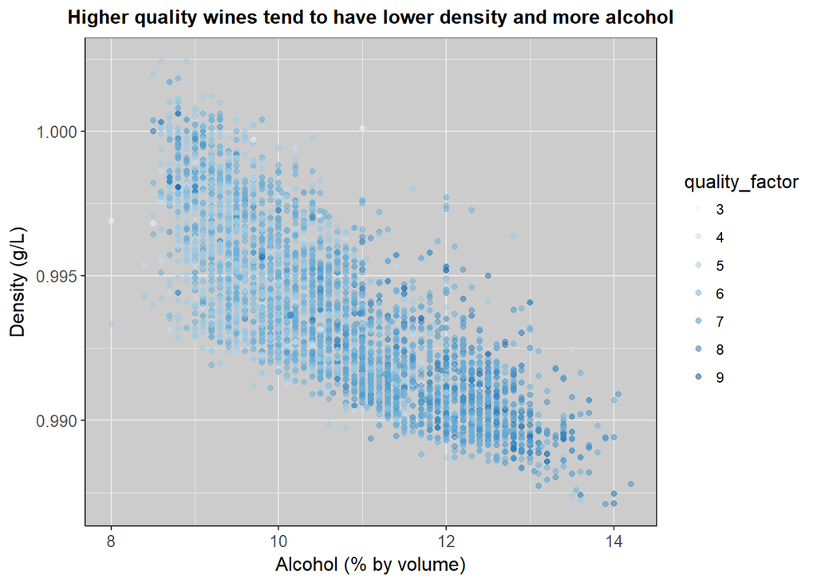

```r
ggplot(aes(x = alcohol, y = density,color = quality_factor),data = df)+
  geom_point(alpha = 1/2)+
  ylim(min(df$density),quantile(df$density,0.999)) +
  scale_color_brewer(type = 'seq') +
  ggtitle('Higher quality wines tend to have lower density and more alcohol') +
  xlab('Alcohol (% by volume)') +
  ylab('Density (g/L)') +
  theme_bw() +
  theme(panel.background = element_rect(fill = 'grey80'),
        axis.line = element_line(colour = "black"),
        axis.text = element_text(size = 10),
        axis.title = element_text(size = 12),
        legend.title = element_text(size = 12),
        plot.title = element_text(size = 12, face = 'bold',hjust = 0.5))
```

## Description three

We learn from plot one that wines of higher quality tends to have more alcohol. The same trend is observed here that those wines tend to cluster on the lower right of the plot.

# Conclusion

The biggest conclusion is that none of the 11 physical/chemical propertiy is strongly correlated with the quality. It is real that the dataset and problem are not that linear or simple. The bimodal distribution of the residual sugar is also interesting that they may come from different fabrication process. Critic acid shows some peaks in the distribution, which may also be due to the fabrication process. Although there are some trends in the observation, it is not clear to draw a quantitive conclusion. More complex regression models and addition variables may help to understand the quality. It is ideal that we could predict the quality of the wine based on the input variables, and it is machine learning which may help on this problem.